# STATS 302 - Assignment 3

Jonathan Kumarich

18/05/2021

### Packages and clear

```r
rm(list=ls())

pacman::p_load(
  ggplot2,
  rstudioapi,
  tinytex,
  dplyr,
  purrr,
  vegan
)

if (!requireNamespace("BiocManager", quietly = TRUE)) install.packages("BiocManager")
BiocManager::install("mixOmics")
library(mixOmics)
```

### Data Import

```r
setwd(dirname(rstudioapi::getActiveDocumentContext()$path))
getwd()
```

```
## [1] "/Users/jonathankumarich/Uni/Uni/STATS 302/Assignments/A3/STATS302-A3"
```

```r
fungal <- read.csv("fungal-all.csv")
fungal.desc <- fungal[, 1:5]
fungal.val <- fungal[ ,-c(1:5)]
rm(fungal)
```

### Question 1

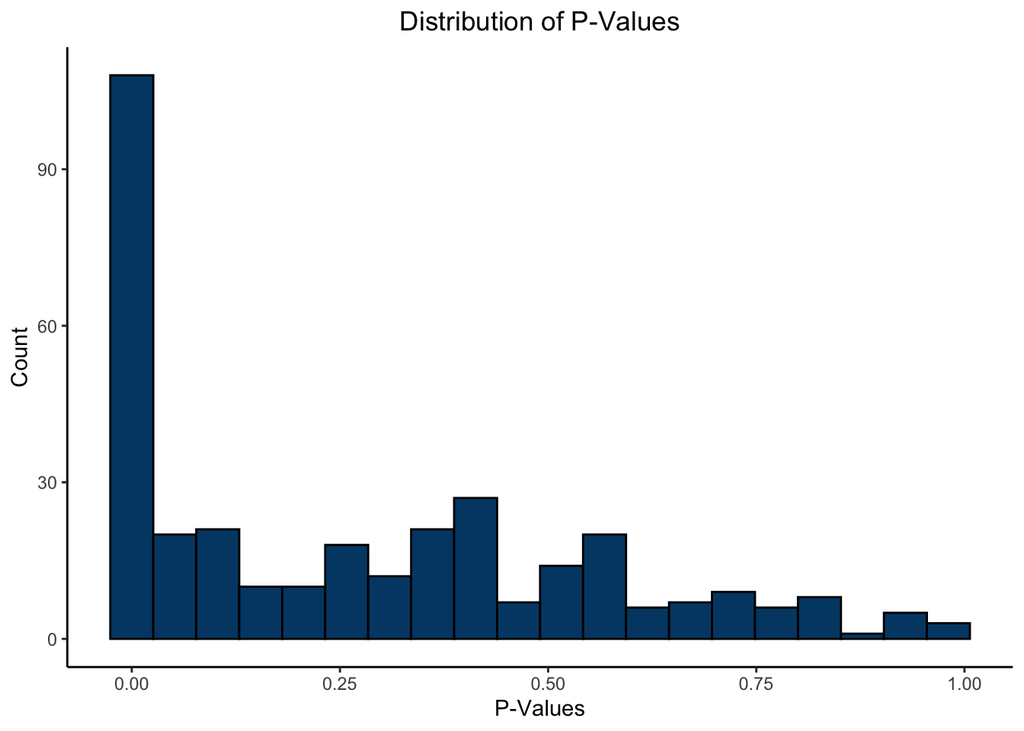

```r
pvals <- rep(NA, ncol(fungal.val))

for (i in 1:ncol(fungal.val)) {
  test <- kruskal.test(fungal.val[, i] ~ fungal.desc$Condition)
  pvals[i] <- test$p.value
}; rm(test)

ggplot(data.frame(pvals), aes(x=pvals)) +
  geom_histogram(fill="#004775", color="black", bins=20) +
  theme_classic() +
  xlab("P-Values") +
  ylab("Count") +
  ggtitle("Distribution of P-Values") +
  theme(plot.title = element_text(hjust = 0.5))
```

If none of the metabolites differed, then by chance, we would have expected around 5% of values to fall under the 0.05 p-value threshold. This would equate to the histogram generally being flat over the whole range of 0 - 1.00. Instead we see a large proportion of p-values appearing in the 0.00 - 0.05 range, indicating that there may be multiple metabolites that differ across conditions.

```r
qval.pi0<-function(pvals, pi0=1){
  #pvals should not have missing values
  #default value of pi0 is 1, but another can be specified.
  ord<-order(pvals, decreasing = TRUE)
  pord<-pvals[ord]
  answer.ord<-rep(NA,length(pvals) )
  answer<-rep(NA, length(pvals))
  denominator<-sum(pord <= pord[1]) #number of discoveries using pord[i] as the threshold
  numerator<- pord[1]*length(pord)*pi0  #expected number of false discoveries
  answer.ord[1]<-numerator/denominator
  for(i in 1: length(pord)){
    denominator<-sum(pord <= pord[i])
    numerator<- pord[i]*length(pord)*pi0
    if( numerator/denominator <= min(answer.ord[1:(i-1)]) ) answer.ord[i]<-numerator/denominator
    if( numerator/denominator > min(answer.ord[1:(i-1)]) ) answer.ord[i]<- min(answer.ord[1:(i-1)])
  }
  answer[ord]<-answer.ord
  return(answer)
}

qvals <- qval.pi0(pvals)

qvals.significant <- sum(qvals < 0.05)

print("Number of observations with significant q-values: " %>% paste0(qvals.significant))
```

```
## [1] "Number of observations with significant q-values: 104"
```

```r
qandp.significant <- sum((qvals >= 0.05) * (pvals < 0.05))

print("Number of observations with significant p-values but non-significant q-values: " %>% paste0(qandp.significant))
```

```
## [1] "Number of observations with significant p-values but non-significant q-values: 16"
```

### Question 2

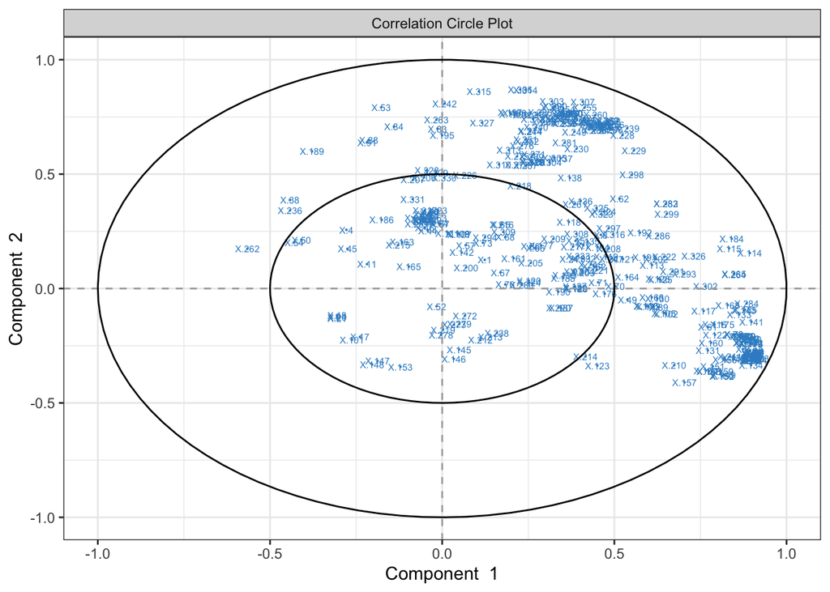

```r
plsda.output <- plsda(X=fungal.val ,Y=fungal.desc$genera, scale=TRUE, ncomp=11)

plotVar(plsda.output, cex=2)
```

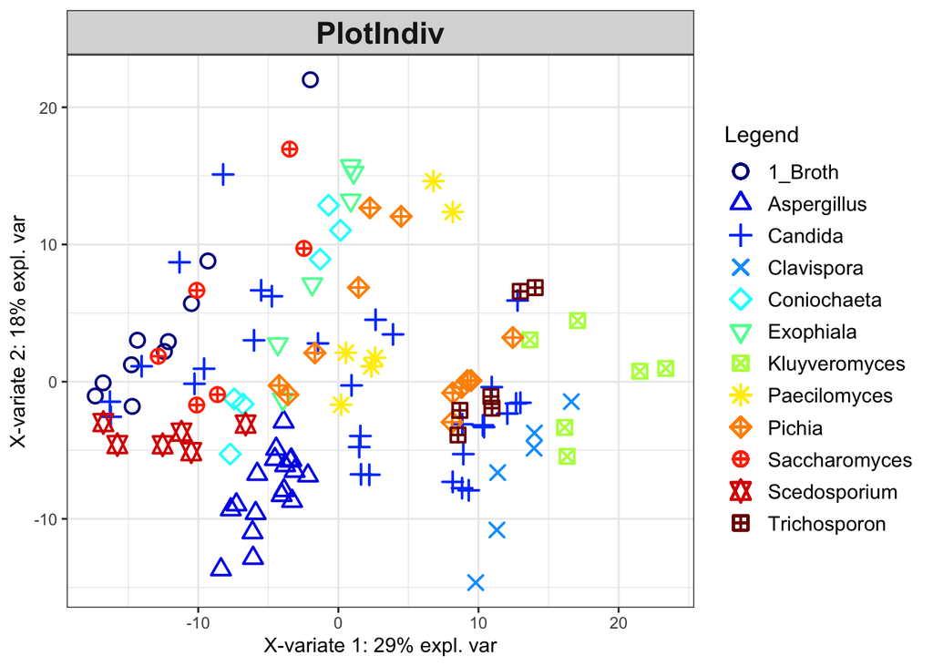

```r
plotIndiv(plsda.output, comp=1:2, ind.names=F, legend=T)
```

We can see from the plot of individuals that a lot of the genera types have been separated out. Genera such as Kluyveromyces, Clavispora, and Trichosporon, all have very high levels of X-variate 1, but all are quite hard to distinguish from each other within this sub-group (except Clavispora which has a lower X-variate 2). On the other hand, the Broth, Scedosporium, and Saccharomyces all have relatively low levels of X-variate 1. Exophiala and Coniochaeta, both have X-variate 1 values centered around zero.

Candida and Pichia are quite hard to distinguish as they seem relatively unrelated to both X-variate 1 and 2.

### Question 3